# DATA 607 Project 3: Dataset 1 Documentation

Full Job Market Analysis and Data Science-Related Job Comparison

DATA 607 Project 3 Team

2026-10-23

# 1 1. Project Overview

## 1.1 Research Question

**Which technical skills appear most frequently across the full job-postings dataset, and how do skill mentions and advertised salaries compare with the Data Science-related subgroup?**

The primary population is the full cleaned job-postings dataset. Data Science-related postings form a smaller, separately classified subgroup for focused comparisons. The project investigates technical skill mentions and advertised annual salary midpoints; these are descriptive associations.

We used R to clean the original dataset, classify relevant occupations, extract technical skills, analyze salary ranges, compare job categories, and validate the results. The full-market and subgroup analyses should be reported separately rather than treating the subgroup as the entire market.

## 1.2 Data Source and Acquisition

The only external dataset used for Dataset 1 is **Job Postings with Salaries** by **minmaxer**, available on Kaggle: https://www.kaggle.com/datasets/minmaxer/job-postings-with-salaries. The dataset was downloaded manually as a ZIP file, extracted, and saved locally for analysis in R. The downloaded snapshot was used rather than treating weekly Kaggle updates as part of the same sample. PostgreSQL was used to store normalized exports and check relationships; the cleaning, classification, and exploratory analysis were performed in R.

**Scope note:** The job-posting dates describe the observed snapshot, not a long-term hiring trend. Skill mentions are identified from job-description text and do not necessarily indicate mandatory qualifications.

## 1.3 Dataset Summary

| Measure | Result |
| --- | --- |
| Full cleaned job postings | 9,173 |
| Original columns | 27 |
| Potentially relevant postings | 892 |
| Initially included postings | 232 |
| Exclusions after initial validation | 3 |
| Additional exclusions after review | 3 |
| Historical revised Data Science subgroup | 226 |
| Historical revised subgroup USD salary sample | 178 |
| Technical skills tracked | 30 |
| Historical revised subgroup median salary midpoint | $165,000 |
| Unresolved candidate postings | 627 |

The full cleaned dataset contains 9,173 postings. The figures for 226 selected jobs and 178 eligible USD salary records describe the earlier manually reviewed Data Science-related subgroup, not the full job market. Updated full-market salary and skill results should be read from the latest Script 09–11 outputs.

These results are descriptive. The full dataset is a limited posting snapshot, while the Data Science-related subgroup is provisional and subject to classification uncertainty.

# 2 Full-Market Analysis: Updated Scripts 09–13

The current project workflow treats **all 9,173 cleaned postings as the primary dataset** and uses Data Science-related postings as a comparison subgroup. The older 226-job results documented later in this report are retained as a historical, manually reviewed analysis and should not be labeled as full-market findings.

## 2.1 Full-Market Dataset Check

```r
full_jobs <- read_csv("Data/job_postings_cleaned.csv", show_col_types = FALSE)

stopifnot(
  all(c("job_id", "posted_at") %in% names(full_jobs)),
  !anyNA(full_jobs$job_id),
  anyDuplicated(full_jobs$job_id) == 0
)

full_jobs %>%
  summarise(
    total_postings = n(),
    unique_postings = n_distinct(job_id),
    missing_dates = sum(is.na(posted_at)),
    first_date = as.Date(min(posted_at, na.rm = TRUE)),
    last_date = as.Date(max(posted_at, na.rm = TRUE))
  ) %>%
  kable(caption = "Full Cleaned Job Market Overview")
```

Full Cleaned Job Market Overview

| total_postings | unique_postings | missing_dates | first_date | last_date |
| --- | --- | --- | --- | --- |
| 9173 | 9173 | 0 | 2026-10-05 | 2026-10-12 |

## 2.2 Full-Market Skill Demand

Script 09 produces full-market technical skill indicators and a Data Science-related comparison. The following section reads the full-market summary when available. The report does not substitute subgroup counts for market-wide counts.

```r
full_skill_path <- "Data/skill_demand_summary_full.csv"

if (file.exists(full_skill_path)) {
  full_skill_summary <- read_csv(full_skill_path, show_col_types = FALSE)
  full_skill_summary %>%
    slice_head(n = 15) %>%
    kable(caption = "Top Technical Skills Across the Full Job Market")
} else {
  cat("Full-market skill summary not found at", full_skill_path,
      "- verify the output filename generated by Script 09.")
}
```

Top Technical Skills Across the Full Job Market

| skill | job_count | percentage | population | total_jobs |
| --- | --- | --- | --- | --- |
| Excel | 1381 | 15.1 | Full Job Market | 9173 |
| Python | 775 | 8.4 | Full Job Market | 9173 |
| SQL | 517 | 5.6 | Full Job Market | 9173 |
| AWS | 485 | 5.3 | Full Job Market | 9173 |
| LLM | 402 | 4.4 | Full Job Market | 9173 |
| R | 382 | 4.2 | Full Job Market | 9173 |
| Azure | 295 | 3.2 | Full Job Market | 9173 |
| Machine Learning | 277 | 3.0 | Full Job Market | 9173 |
| Kubernetes | 274 | 3.0 | Full Job Market | 9173 |
| Statistics | 254 | 2.8 | Full Job Market | 9173 |
| Google Cloud | 250 | 2.7 | Full Job Market | 9173 |
| Generative AI | 204 | 2.2 | Full Job Market | 9173 |
| Power BI | 173 | 1.9 | Full Job Market | 9173 |
| Data Pipelines | 166 | 1.8 | Full Job Market | 9173 |
| Docker | 143 | 1.6 | Full Job Market | 9173 |

### 2.2.1 Full-Market Skill Chart

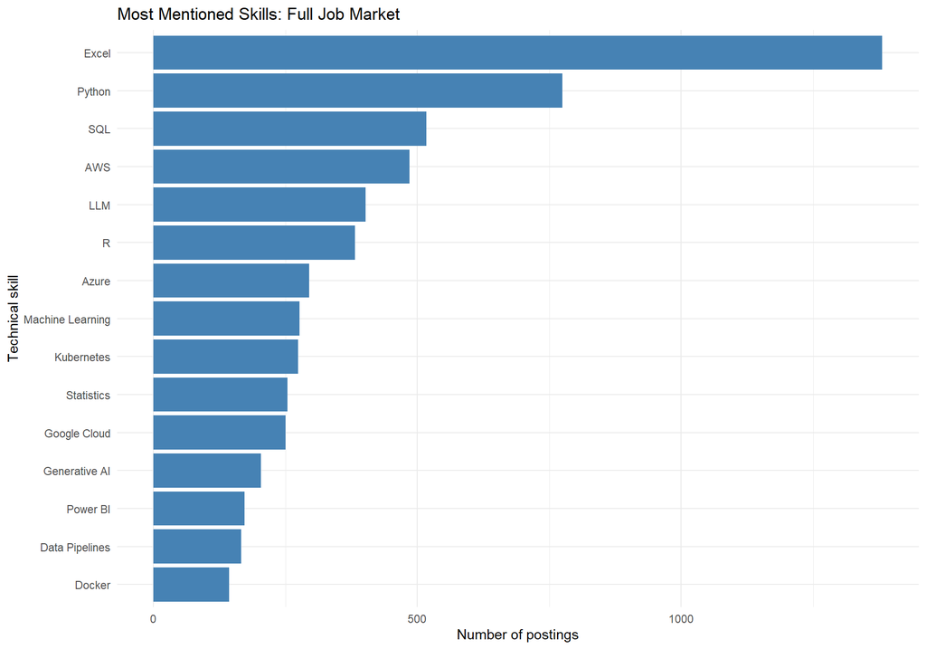

```r
if (exists("full_skill_summary") &&
    all(c("skill", "job_count") %in% names(full_skill_summary))) {
  full_skill_summary %>%
    slice_max(job_count, n = 15, with_ties = FALSE) %>%
    mutate(skill = str_replace_all(skill, "_", " ")) %>%
    ggplot(aes(x = reorder(skill, job_count), y = job_count)) +
    geom_col(fill = "steelblue") +
    coord_flip() +
    labs(title = "Most Mentioned Skills: Full Job Market",
         x = "Technical skill", y = "Number of postings") +
    theme_minimal()
} else {
  cat("Full-market skill chart requires the skill and job_count columns from Script 09.")
}
```

## 2.3 Full-Market Salary Analysis

Script 10 separately analyzes salary-eligible postings in the full market and in the Data Science-related subgroup. Salary comparisons use the midpoint of valid, eligible annual USD salary ranges. The number of eligible records and overall median should be calculated from the saved full-market output rather than inferred from the subgroup.

```r
full_salary_path <- "Data/jobs_salary_analysis_full.csv"

if (file.exists(full_salary_path)) {
  full_salary_jobs <- read_csv(full_salary_path, show_col_types = FALSE)
  stopifnot("salary_midpoint_annual" %in% names(full_salary_jobs))
  full_salary_jobs %>%
    summarise(
      eligible_postings = n(),
      median_salary_midpoint = median(salary_midpoint_annual, na.rm = TRUE),
      mean_salary_midpoint = mean(salary_midpoint_annual, na.rm = TRUE)
    ) %>%
    kable(caption = "Full-Market Eligible USD Salary Summary")
} else {
  cat("Full-market salary file not found at", full_salary_path,
      "- verify the output filename generated by Script 10.")
}
```

Full-Market Eligible USD Salary Summary

| eligible_postings | median_salary_midpoint | mean_salary_midpoint |
| --- | --- | --- |
| 7590 | 110000 | 121499.5 |

### 2.3.1 Full-Market Salary Distribution

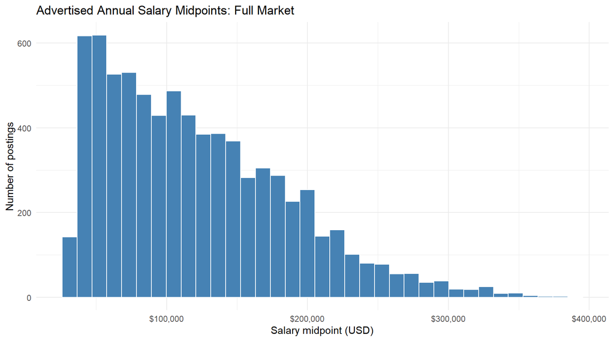

```r
if (exists("full_salary_jobs") &&
    "salary_midpoint_annual" %in% names(full_salary_jobs)) {
  full_salary_jobs %>%
    filter(is.finite(salary_midpoint_annual)) %>%
    ggplot(aes(x = salary_midpoint_annual)) +
    geom_histogram(bins = 35, fill = "steelblue", color = "white") +
    scale_x_continuous(labels = label_dollar()) +
    labs(title = "Advertised Annual Salary Midpoints: Full Market",
         x = "Salary midpoint (USD)", y = "Number of postings") +
    theme_minimal()
} else {
  cat("Full-market salary chart requires Script 10's eligible salary export.")
}
```

## 2.4 Job Categories and Normalization

Script 11 compares full-market salaries with the separately classified Data Science-related categories. Script 13 exports the core six normalized relational tables; the current supplied CSV snapshot includes a seventh table, `job_sector_classification`. The PostgreSQL and Shiny results in the later sections of this document describe the **previously verified 226-posting subgroup implementation** unless the database and dashboard have been explicitly rebuilt using the new full-market exports. Updating R scripts alone does not update a PostgreSQL database or an online dashboard.

## 2.5 Current Seven-Table Relational Dataset (Verified CSV Snapshot)

| Table | CSV rows | Primary key | Role |
| --- | --- | --- | --- |
| `company` | 3,969 | `company_id` | Employers |
| `job_posting` | 9,173 | `job_id` | Full-market job postings |
| `salary` | 9,173 | `job_id` (PK/FK) | Salary information for each posting, including ineligible records |
| `skill` | 30 | `skill_id` | Technical skill dictionary |
| `job_skill` | 7,140 | (`job_id`, `skill_id`) | Detected job-to-skill links |
| `data_science_classification` | 229 | `job_id` (PK/FK) | Data Science-related subgroup |
| `job_sector_classification` | 9,173 | `job_id` (PK/FK) | Sector classification for all postings |

These counts were checked against the **seven supplied CSV files**, not against a live PostgreSQL connection. The 229 Data Science classification rows are from the current uploaded snapshot; the older 226/178 figures refer to the separately reviewed historical analysis. The `salary` table contains 9,173 rows, **not** 9,173 salary-eligible jobs. The `job_skill` count is 7,140 detected associations, not 7,140 distinct jobs.

**Relationships:** `company` 1-to-many `job_posting`; `job_posting` 1-to-1 `salary`; `job_posting` 1-to-many `job_skill`; `skill` 1-to-many `job_skill`; `job_posting` 1-to-0-or-1 `data_science_classification`; and `job_posting` 1-to-1 `job_sector_classification` in this snapshot. The two classification tables refer to `job_posting.job_id`. These are relationships inferred and checked from CSV keys, not proof that foreign-key constraints have been deployed in PostgreSQL.

```r
# Place the seven exports in Dashboard_Online/data/ (or adjust this path).
files <- c("company", "job_posting", "salary", "skill", "job_skill",
           "data_science_classification", "job_sector_classification")
tables <- setNames(lapply(files, function(nm) {
  readr::read_csv(file.path("Dashboard_Online", "data", paste0(nm, ".csv")),
                  show_col_types = FALSE)
}), files)
stopifnot(
  nrow(tables$job_posting) == 9173,
  nrow(tables$salary) == 9173,
  nrow(tables$data_science_classification) == 229,
  nrow(tables$job_sector_classification) == 9173,
  nrow(tables$job_skill) == 7140,
  !anyDuplicated(tables$job_posting$job_id),
  !anyDuplicated(tables$job_sector_classification$job_id),
  all(tables$job_sector_classification$job_id %in% tables$job_posting$job_id),
  all(tables$data_science_classification$job_id %in% tables$job_posting$job_id)
)
knitr::kable(data.frame(table = files, rows = vapply(tables, nrow, integer(1))))
```

[output not shown]

# 3 2. Project Organization

The project uses a sequence of R scripts:

- `01_explore_jobs.R`
- `02_clean_jobs.R`
- `03_validate_jobs.R`
- `04_refine_jobs.R`
- `05_review_classification.R`
- `06_finalize_job_classification.R`
- `07_improve_job_classification.R`
- `08_validate_classification.R`
- `09_analyze_skills.R`
- `10_analyze_skill_salaries.R`
- `11_analyze_job_categories.R`
- `12_validate_results.R`
- `12B_review_exceptions.R`
- `12C_apply_review_decisions.R`
- `13_normalize_dataset.R` (relational database export)

The original dataset, intermediate CSV files, validation files, and charts are stored in the `Data/` folder.

The original analysis outputs are preserved separately from the revised results.

# 4 3. Step 01: Explore Original Job Postings

**Script:** `01_explore_jobs.R`

## 4.1 Objective

Understand the structure, contents, and quality of the original job-postings dataset.

## 4.2 Input

`Data/job_postings_with_salaries.csv`

## 4.3 Methods

We examined:

- Total rows and columns
- Column names and data types
- Missing values
- Job titles and descriptions
- Minimum and maximum advertised salaries
- Salary currencies

## 4.4 Results

The original dataset contained 9,173 postings and 27 columns.

A total of 9,155 records had complete, valid annual salary values.

| Currency | Records |
| --- | --- |
| USD | 7,796 |
| EUR | 527 |
| CAD | 499 |
| GBP | 254 |
| AUD | 57 |
| PLN | 26 |
| NZD | 10 |
| CHF | 4 |

We decided not to combine salaries from different currencies without conversion.

# 5 4. Step 02: Clean Job Postings

**Script:** `02_clean_jobs.R`

## 5.1 Objective

Clean the original dataset and identify potentially relevant data science jobs.

## 5.2 Methods

We standardized text, checked identifiers, examined salary information, and created indicators for valid and eligible salaries.

USD salary ranges were flagged as potential outliers when the minimum salary was below $30,000 or the maximum salary exceeded $400,000.

A total of 203 records were flagged by this rule.

We also searched titles, departments, and descriptions for data science-related terminology.

## 5.3 Results

The screening process identified 892 potentially relevant postings.

## 5.4 Outputs

- `job_postings_cleaned.csv`
- `job_postings_data_science.csv`
- `job_postings_review.csv`
- `job_titles_summary.csv`

The preliminary `skill_count` variable created during cleaning was not used as the final technical-skill measure.

# 6 5. Step 03: Initial Manual Validation

**Script:** `03_validate_jobs.R`

## 6.1 Objective

Evaluate whether the initial screening rules correctly identified relevant occupations.

## 6.2 Methods

We generated a sample of 30 postings and prepared a review template containing titles, descriptions, and classification fields.

The purpose was to identify false positives, such as general software engineering positions mentioning Python without primarily involving data science.

## 6.3 Outputs

- `job_review_sample.csv`
- `job_manual_review.csv`

The initial review template was not fully completed, so this step was primarily review preparation.

# 7 6. Step 04: Refine Job Classification

**Script:** `04_refine_jobs.R`

## 7.1 Objective

Separate clearly relevant, uncertain, and unrelated postings.

## 7.2 Results

| Classification | Jobs |
| --- | --- |
| Likely Relevant | 301 |
| Needs Review | 557 |
| Likely Unrelated | 34 |
| Total | 892 |

The classifications were generated using job titles and contextual rules.

These were preliminary rule-based labels.

## 7.3 Outputs

- `job_postings_refined_all.csv`
- `job_postings_relevant.csv`
- `job_postings_uncertain.csv`

# 8 7. Step 05: Review Classification Errors

**Script:** `05_review_classification.R`

## 8.1 Objective

Investigate potential false positives and false negatives.

## 8.2 Methods

We created diagnostic queues for jobs that might have been classified incorrectly.

## 8.3 Results

- 80 possible false positives
- 557 uncertain potential false negatives

## 8.4 Outputs

- `possible_false_positives.csv`
- `possible_false_negatives.csv`

These files helped identify weaknesses in broad keyword matching.

# 9 8. Step 06: Finalize Initial Classification

**Script:** `06_finalize_job_classification.R`

## 9.1 Objective

Apply stricter occupation-based classification rules.

## 9.2 Methods

We developed patterns for:

- Data Science
- Data Analytics
- Data Engineering
- AI and Machine Learning
- Business Intelligence
- Statistics
- Database Management

## 9.3 Results

| Classification | Jobs |
| --- | --- |
| Include | 213 |
| Review | 646 |
| Exclude | 33 |
| Total | 892 |

Among the 213 provisionally included jobs, 164 had eligible USD salary information.

## 9.4 Outputs

- `jobs_classified_all.csv`
- `jobs_include_provisional.csv`
- `jobs_manual_review_queue.csv`

# 10 9. Step 07: Improve Classification

**Script:** `07_improve_job_classification.R`

## 10.1 Objective

Identify relevant specialized occupations missed by the earlier classification rules.

## 10.2 Methods

We expanded patterns to include roles such as:

- MLOps Engineer
- LLM Engineer
- Generative AI Engineer
- Data Platform Engineer
- Data Infrastructure Engineer
- Analytics Director
- Biostatistics-related positions

## 10.3 Results

| Classification | Jobs |
| --- | --- |
| Include | 232 |
| Review | 627 |
| Exclude | 33 |
| Total | 892 |

### 10.3.1 Distribution of Provisionally Included Jobs

| Category | Jobs |
| --- | --- |
| AI/ML | 63 |
| Data Engineering | 55 |
| Data Analytics | 49 |
| Data Science | 41 |
| Statistics | 10 |
| Database | 8 |
| Business Intelligence | 6 |
| Total | 232 |

## 10.4 Outputs

- `jobs_classified_updated.csv`
- `jobs_include_updated.csv`
- `jobs_review_remaining.csv`

# 11 10. Step 08: Validate Included Jobs

**Script:** `08_validate_classification.R`

## 11.1 Objective

Evaluate the relevance of the updated inclusion rules.

## 11.2 Methods

We prepared a validation sample containing 19 newly included jobs and 30 randomly selected previously included jobs.

## 11.3 Results

| Decision | Jobs |
| --- | --- |
| Relevant | 46 |
| Not Relevant | 3 |
| Total | 49 |

The three excluded postings were:

1. Artificial Intelligence & Machine Learning, AVP
2. Manager, Product Owner - AI/ML & Market Insights
3. Data Annotation Specialist - Computer Vision

The observed relevant proportion was:

```r
46 / 49 * 100
```

```
## [1] 93.87755
```

Approximately 93.9% of the reviewed sample was classified as relevant.

However, this was not a fully random validation sample. The percentage should not be interpreted as the overall accuracy of the classifier.

## 11.4 Outputs

- `jobs_validation_sample.csv`
- `jobs_validation_reviewed.csv`

# 12 11. Step 09: Historical Data Science Subgroup Skill Analysis

**Script:** `09_analyze_skills.R`

## 12.1 Objective

Determine which technical skills appeared most frequently in selected postings.

## 12.2 Methods

We began with 232 provisionally included jobs and excluded the three postings identified during initial validation.

This produced an initial analysis sample of 229 jobs.

We defined 30 regular-expression skill indicators and searched job descriptions for technical skill mentions.

Each job was counted at most once per skill.

The initial analysis produced 1,142 job-skill matches.

## 12.3 Initial Results

| Skill | Jobs | Percentage |
| --- | --- | --- |
| Python | 163 | 71.2% |
| SQL | 133 | 58.1% |
| Machine Learning | 74 | 32.3% |
| LLM | 60 | 26.2% |
| Statistics | 55 | 24.0% |
| Data Pipelines | 54 | 23.6% |
| dbt | 51 | 22.3% |
| AWS | 47 | 20.5% |
| Snowflake | 38 | 16.6% |
| Databricks | 33 | 14.4% |

These are historical results from the 229-job sample. The revised findings appear in Step 12C.

## 12.4 Technical Correction

During development, `pivot_longer()` initially produced an error because a numeric `skill_count` column was included with logical skill indicators.

We corrected this by excluding the numeric column before reshaping.

## 12.5 Outputs

- `jobs_skills_analyzed.csv`
- `job_skills_long.csv`
- `skill_demand_summary.csv`
- `top_15_skills.png`

# 13 12. Step 10: Historical Data Science Subgroup Skill and Salary Analysis

**Script:** `10_analyze_skill_salaries.R`

## 13.1 Objective

Investigate the relationship between technical skill mentions and advertised annual salaries.

## 13.2 Methods

We selected postings with eligible USD salary information and valid annual minimum and maximum salary values.

The initial salary sample contained 180 postings.

For each posting, the advertised salary midpoint was calculated as:

$$\text{Salary Midpoint} =
\frac{\text{Minimum Salary}+\text{Maximum Salary}}{2}$$

## 13.3 Initial Results

The overall median advertised annual salary midpoint was $165,000.

| Skill | Salary Jobs | Median Salary |
| --- | --- | --- |
| Generative AI | 15 | $196,500 |
| PyTorch | 23 | $195,050 |
| Deep Learning | 13 | $193,300 |
| LLM | 51 | $190,900 |
| Kubernetes | 15 | $185,000 |
| Machine Learning | 59 | $182,200 |
| Data Pipelines | 42 | $182,025 |

We also compared median salaries for postings mentioning each skill against postings not mentioning that skill.

These comparisons were unadjusted descriptive associations, not causal salary premiums.

## 13.4 Outputs

- `jobs_salary_analysis.csv`
- `skill_salary_summary.csv`
- `skill_salary_comparison.csv`
- `skill_salary_chart.png`

# 14 13. Step 11: Historical Data Science Subgroup Job Category Analysis

**Script:** `11_analyze_job_categories.R`

## 14.1 Objective

Examine salary differences across job categories and investigate whether occupation type influences skill-salary relationships.

## 14.2 Initial Results

| Category | Jobs | Median Salary |
| --- | --- | --- |
| AI/ML | 51 | $190,000 |
| Data Science | 28 | $188,250 |
| Statistics | 10 | $179,500 |
| Data Engineering | 40 | $170,000 |
| Database | 7 | $152,500 |
| Data Analytics | 40 | $118,750 |
| Business Intelligence | 4 | $114,213 |

Within the Data Analytics category, postings mentioning SQL had a median salary midpoint of $125,000, compared with $112,500 for postings not mentioning SQL.

This illustrates why overall salary comparisons can differ from within-category comparisons.

## 14.3 Outputs

- `job_category_salary_summary.csv`
- `category_skill_salary_summary.csv`
- `job_category_salary_chart.png`

# 15 14. Step 12: Validate Analysis Results

**Script:** `12_validate_results.R`

## 15.1 Objective

Check the quality and consistency of the skill and salary datasets.

## 15.2 Validation Results

| Check | Result |
| --- | --- |
| Initial skill-analysis jobs | 229 |
| Initial salary-analysis jobs | 180 |
| Duplicate job IDs | 0 |
| Repeated title/company rows | 8 |
| Jobs with zero detected tracked skills | 9 |
| Missing logical skill indicators | 0 |
| Invalid salary ranges | 0 |
| Salary midpoint mismatches | 0 |
| Non-USD records in salary sample | 0 |

The repeated title/company records represented four pairs of postings.

These were retained because they appeared to represent distinct advertised openings, including location-specific postings.

## 15.3 Salary Distribution

The initial salary-analysis sample had:

| Statistic | Value |
| --- | --- |
| Minimum | $39,000 |
| First Quartile | $122,500 |
| Median | $165,000 |
| Mean | $166,753 |
| Third Quartile | $201,150 |
| Maximum | $338,000 |

The seniority field was predominantly classified as Unknown, limiting our ability to make reliable seniority-adjusted comparisons.

# 16 15. Step 12B: Review Classification Exceptions

**Script:** `12B_review_exceptions.R`

## 16.1 Objective

Review the nine jobs with no detected tracked skills and determine whether they belong in the selected occupational sample.

## 16.2 Review Decisions

| Job | Final Decision |
| --- | --- |
| Senior Quantitative Researcher | Include |
| Applied AI Engineer, GTM | Exclude |
| Informatics Analyst | Include |
| Manager, Marketing Analytics | Include |
| Data Analytics Manager | Include |
| Data Scientist - Sensor Technician | Exclude |
| Lead Engineer, Testing and Qualification | Exclude |
| Senior Staff Data Scientist | Include |
| Business Information Data Architect | Include |

Six postings were retained and three were excluded.

The three excluded jobs primarily involved go-to-market operations, sensor systems, or engineering testing outside our selected occupational scope.

The retained jobs involved relevant research, analytics, informatics, or data architecture responsibilities.

## 16.3 Important Observation

Having zero matches among our tracked skills does not necessarily mean a posting is unrelated to data science.

It can also indicate that the job description uses terminology not captured by our regular-expression dictionary.

## 16.4 Review Output

`validation_manual_review_sheet_completed.csv`

# 17 16. Step 12C: Apply Reviewed Decisions

**Script:** `12C_apply_review_decisions.R`

## 17.1 Objective

Apply the three additional exclusions and recompute the analysis using a revised sample.

## 17.2 Revised Sample

| Measure | Original | Revised |
| --- | --- | --- |
| Skill-analysis jobs | 229 | 226 |
| Salary-analysis jobs | 180 | 178 |
| Median salary midpoint | $165,000 | $165,000 |

The additional exclusions did not change the overall median salary midpoint.

The original files were preserved, and revised datasets were created separately.

## 17.3 16.1 Revised Skill Demand

The following code reads the revised skill-demand results.

```r
skill_demand_revised <- read_csv(
  "Data/skill_demand_revised.csv",
  show_col_types = FALSE
)

skill_demand_revised %>%
  slice_head(n = 15) %>%
  mutate(
    skill = str_replace_all(skill, "_", " ")
  ) %>%
  kable(
    caption = "Top 15 Technical Skills - Revised Sample"
  )
```

Top 15 Technical Skills - Revised Sample

| skill | job_count | percentage |
| --- | --- | --- |
| python | 163 | 72.1 |
| sql | 133 | 58.8 |
| machine learning | 74 | 32.7 |
| llm | 60 | 26.5 |
| statistics | 55 | 24.3 |
| data pipelines | 54 | 23.9 |
| dbt | 51 | 22.6 |
| aws | 47 | 20.8 |
| snowflake | 38 | 16.8 |
| databricks | 33 | 14.6 |
| azure | 30 | 13.3 |
| etl | 29 | 12.8 |
| tableau | 29 | 12.8 |
| google cloud | 28 | 12.4 |
| power bi | 27 | 11.9 |

### 17.3.1 Revised Skill Demand Findings

| Skill | Jobs | Percentage |
| --- | --- | --- |
| Python | 163 | 72.1% |
| SQL | 133 | 58.8% |
| Machine Learning | 74 | 32.7% |
| LLM | 60 | 26.5% |
| Statistics | 55 | 24.3% |
| Data Pipelines | 54 | 23.9% |
| dbt | 51 | 22.6% |
| AWS | 47 | 20.8% |
| Snowflake | 38 | 16.8% |
| Databricks | 33 | 14.6% |

Python and SQL remained the two most frequently mentioned skills.

The skill counts were unchanged because the three excluded postings contained no detected tracked skills.

The percentages increased slightly because the denominator decreased from 229 to 226.

### 17.3.2 Revised Skill Demand Chart

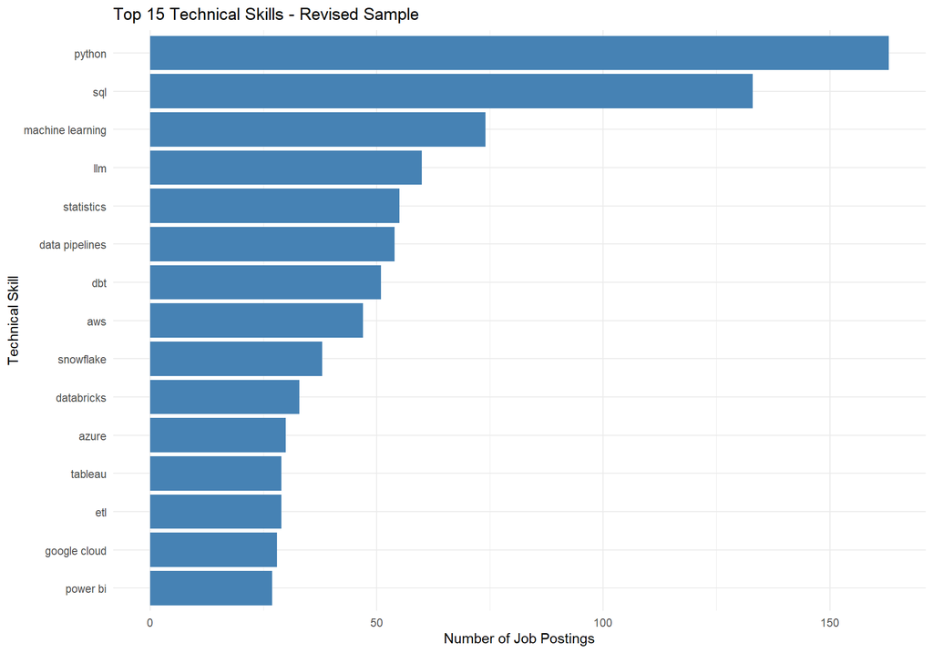

```r
skill_demand_revised %>%
  slice_max(
    job_count,
    n = 15,
    with_ties = FALSE
  ) %>%
  mutate(
    skill = str_replace_all(skill, "_", " ")
  ) %>%
  ggplot(
    aes(
      x = reorder(skill, job_count),
      y = job_count
    )
  ) +
  geom_col(fill = "steelblue") +
  coord_flip() +
  labs(
    title = "Top 15 Technical Skills - Revised Sample",
    x = "Technical Skill",
    y = "Number of Job Postings"
  ) +
  theme_minimal()
```

## 17.4 16.2 Revised Salary Analysis

The revised salary sample contains 178 eligible USD postings.

```r
salary_summary_revised <- read_csv(
  "Data/salary_summary_revised.csv",
  show_col_types = FALSE
)

salary_summary_revised %>%
  mutate(
    across(
      c(
        mean_salary,
        median_salary,
        min_salary,
        max_salary
      ),
      ~ dollar(.x)
    )
  ) %>%
  kable(
    caption = "Revised Overall Salary Summary"
  )
```

Revised Overall Salary Summary

| job_count | mean_salary | median_salary | min_salary | max_salary |
| --- | --- | --- | --- | --- |
| 178 | $166,885 | $165,000 | $39,000 | $338,000 |

The median advertised annual salary midpoint remained $165,000.

### 17.4.1 Revised Salary by Skill

```r
skill_salary_revised <- read_csv(
  "Data/skill_salary_revised.csv",
  show_col_types = FALSE
)

skill_salary_revised %>%
  filter(job_count >= 10) %>%
  arrange(desc(median_salary)) %>%
  mutate(
    skill = str_replace_all(skill, "_", " "),
    median_salary = dollar(median_salary),
    mean_salary = dollar(mean_salary)
  ) %>%
  kable(
    caption = "Revised Median Advertised Salary by Skill"
  )
```

Revised Median Advertised Salary by Skill

| skill | job_count | median_salary | mean_salary |
| --- | --- | --- | --- |
| generative ai | 15 | $196,500 | $180,125 |
| pytorch | 23 | $195,050 | $195,138 |
| deep learning | 13 | $193,300 | $190,904 |
| llm | 51 | $190,900 | $183,070 |
| kubernetes | 15 | $185,000 | $181,003 |
| machine learning | 59 | $182,200 | $179,780 |
| data pipelines | 42 | $182,025 | $180,093 |
| scikit learn | 10 | $181,775 | $188,360 |
| tensorflow | 13 | $180,000 | $172,832 |
| nlp | 12 | $176,800 | $163,543 |
| spark | 19 | $176,800 | $178,541 |
| aws | 40 | $169,250 | $168,589 |
| airflow | 16 | $168,750 | $164,761 |
| etl | 23 | $168,500 | $165,980 |
| google cloud | 23 | $168,500 | $159,655 |
| python | 131 | $165,000 | $166,020 |
| statistics | 44 | $164,900 | $172,225 |
| snowflake | 32 | $164,250 | $170,970 |
| looker | 15 | $162,972 | $162,669 |
| dbt | 37 | $156,000 | $160,959 |
| databricks | 28 | $155,000 | $156,493 |
| sql | 105 | $152,500 | $156,390 |
| r | 22 | $151,160 | $152,373 |
| git | 18 | $149,216 | $163,695 |
| azure | 25 | $148,012 | $154,537 |
| tableau | 26 | $123,750 | $129,717 |
| data visualization | 17 | $119,500 | $121,629 |
| power bi | 20 | $112,170 | $119,878 |
| excel | 19 | $107,016 | $108,370 |

### 17.4.2 Selected Revised Results

| Skill | Jobs | Median Salary |
| --- | --- | --- |
| Generative AI | 15 | $196,500 |
| PyTorch | 23 | $195,050 |
| Deep Learning | 13 | $193,300 |
| LLM | 51 | $190,900 |
| Kubernetes | 15 | $185,000 |
| Machine Learning | 59 | $182,200 |
| Data Pipelines | 42 | $182,025 |
| Python | 131 | $165,000 |
| SQL | 105 | $152,500 |
| Tableau | 26 | $123,750 |
| Power BI | 20 | $112,170 |
| Excel | 19 | $107,016 |

These findings suggest that specialized AI-related skills appeared in postings with relatively high advertised salary midpoints.

However, they do not establish that possessing these skills causes higher salaries.

### 17.4.3 Revised Skill Salary Chart

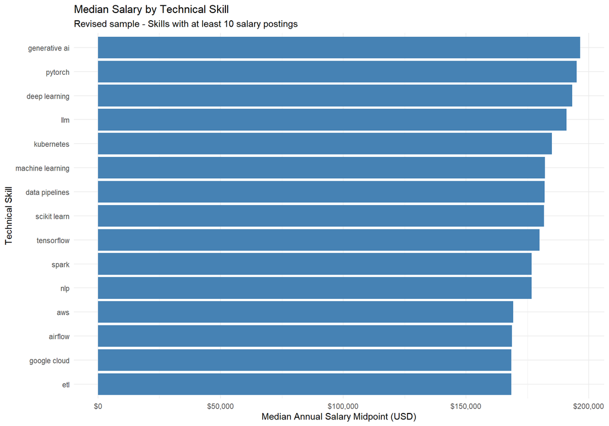

```r
skill_salary_revised %>%
  filter(job_count >= 10) %>%
  slice_max(
    median_salary,
    n = 15,
    with_ties = FALSE
  ) %>%
  mutate(
    skill = str_replace_all(skill, "_", " ")
  ) %>%
  ggplot(
    aes(
      x = reorder(skill, median_salary),
      y = median_salary
    )
  ) +
  geom_col(fill = "steelblue") +
  coord_flip() +
  scale_y_continuous(
    labels = label_dollar()
  ) +
  labs(
    title = "Median Salary by Technical Skill",
    subtitle = "Revised sample - Skills with at least 10 salary postings",
    x = "Technical Skill",
    y = "Median Annual Salary Midpoint (USD)"
  ) +
  theme_minimal()
```

## 17.5 16.3 Revised Salary by Job Category

```r
category_salary_revised <- read_csv(
  "Data/category_salary_revised.csv",
  show_col_types = FALSE
)

category_salary_revised %>%
  mutate(
    median_salary = dollar(median_salary),
    mean_salary = dollar(mean_salary)
  ) %>%
  kable(
    caption = "Revised Salary by Job Category"
  )
```

Revised Salary by Job Category

| job_category_updated | job_count | median_salary | mean_salary |
| --- | --- | --- | --- |
| Data Science | 27 | $196,500 | $176,651 |
| AI/ML | 50 | $191,250 | $186,622 |
| Statistics | 10 | $179,500 | $185,167 |
| Data Engineering | 40 | $170,000 | $175,928 |
| Database | 7 | $152,500 | $154,703 |
| Data Analytics | 40 | $118,750 | $130,191 |
| Business Intelligence | 4 | $114,213 | $106,357 |

### 17.5.1 Revised Category Results

| Category | Jobs | Median Salary |
| --- | --- | --- |
| Data Science | 27 | $196,500 |
| AI/ML | 50 | $191,250 |
| Statistics | 10 | $179,500 |
| Data Engineering | 40 | $170,000 |
| Database | 7 | $152,500 |
| Data Analytics | 40 | $118,750 |
| Business Intelligence | 4 | $114,213 |

Data Science had the highest median advertised salary midpoint in the revised sample, followed by AI/ML.

These comparisons are sensitive to job composition and sample size.

### 17.5.2 Revised Category Salary Chart

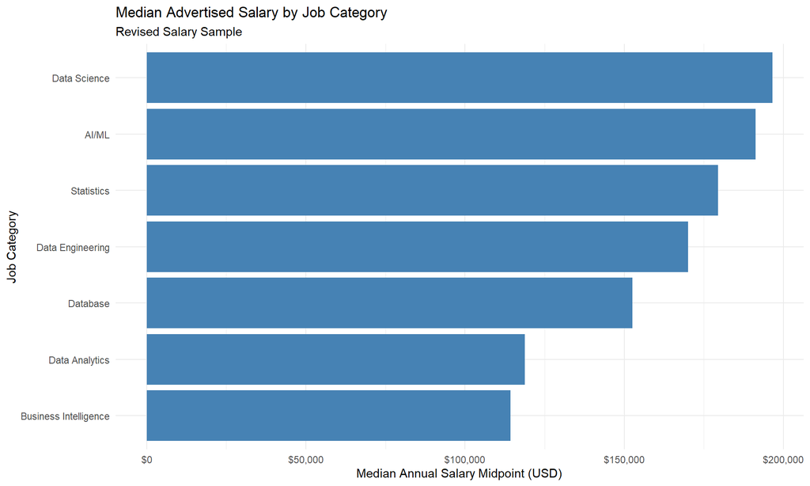

```r
category_salary_revised %>%
  ggplot(
    aes(
      x = reorder(
        job_category_updated,
        median_salary
      ),
      y = median_salary
    )
  ) +
  geom_col(fill = "steelblue") +
  coord_flip() +
  scale_y_continuous(
    labels = label_dollar()
  ) +
  labs(
    title = "Median Advertised Salary by Job Category",
    subtitle = "Revised Salary Sample",
    x = "Job Category",
    y = "Median Annual Salary Midpoint (USD)"
  ) +
  theme_minimal()
```

## 17.6 16.4 Revised Data Quality Checks

```r
jobs_revised <- read_csv(
  "Data/jobs_skills_revised.csv",
  show_col_types = FALSE
)

salary_revised <- read_csv(
  "Data/jobs_salary_revised.csv",
  show_col_types = FALSE
)

comparison <- read_csv(
  "Data/validation_original_vs_revised.csv",
  show_col_types = FALSE
)

stopifnot(
  nrow(jobs_revised) == 226,
  nrow(salary_revised) == 178,
  anyDuplicated(jobs_revised$job_id) == 0,
  anyDuplicated(salary_revised$job_id) == 0
)

comparison %>%
  kable(
    caption = "Original vs Revised Analysis"
  )
```

Original vs Revised Analysis

| measure | original | revised |
| --- | --- | --- |
| Full-market skill jobs (unchanged) | 9173 | 9173 |
| Data Science skill jobs | 229 | 226 |
| Data Science eligible salary jobs | 180 | 178 |
| Data Science median salary | 165000 | 165000 |

## 17.7 16.5 Validation Conclusion

The additional review improved the occupational relevance of our selected sample.

Removing three unrelated postings did not change the overall median salary midpoint or the ranking of the most frequently mentioned technical skills.

The results remained stable under this limited exclusion sensitivity check.

However, this does not establish that the full classification process or skill extraction dictionary is accurate.

# 18 17. Historical Data Science Subgroup Research Findings

## 18.1 Finding 1: Python and SQL Are Most Frequently Mentioned

Python appeared in 163 of 226 selected postings, representing 72.1%.

SQL appeared in 133 postings, representing 58.8%.

These were the two most frequently detected technical skills in the revised sample.

## 18.2 Finding 2: Specialized AI Skills Appear in Higher-Salary Postings

Generative AI, PyTorch, Deep Learning, and LLMs appeared in postings with relatively high median advertised salary midpoints.

For example:

- Generative AI: $196,500
- PyTorch: $195,050
- Deep Learning: $193,300
- LLM: $190,900

These are descriptive associations within the selected sample.

## 18.3 Finding 3: Job Category Matters

Data Science and AI/ML postings had higher median salary midpoints than Data Analytics and Business Intelligence postings.

This suggests that occupational composition is an important consideration when interpreting skill-salary relationships.

## 18.4 Finding 4: Overall Skill Comparisons Can Be Misleading

The initial analysis found a negative overall salary difference for SQL mentions.

However, within the Data Analytics category, SQL-mentioning postings had a higher median salary midpoint.

This demonstrates that relationships observed across all jobs may differ from relationships observed within particular occupations.

## 18.5 Finding 5: Machine Learning Salary Associations Vary Within Job Categories

Comparing salary-eligible postings within the same job category reveals that a machine learning mention does not consistently correspond to a higher advertised salary midpoint. The following results were verified using `jobs_skills_revised.csv` and the 178 eligible USD salary records.

| Job Category | Jobs Without ML | Median Without ML | Jobs With ML | Median With ML |
| --- | --- | --- | --- | --- |
| AI/ML | 21 | $183,550 | 29 | $192,500 |
| Data Analytics | 34 | $117,750 | 6 | $154,910 |
| Data Engineering | 35 | $170,000 | 5 | $168,500 |
| Data Science | 11 | $208,000 | 16 | $166,960 |
| Database | 6 | $151,460 | 1 | $182,500 |
| Statistics | 8 | $179,400 | 2 | $207,500 |

Business Intelligence had four salary-eligible postings, none of which mentioned machine learning, so no within-category comparison was possible. Differences in medians are descriptive, not causal effects; the groups are small in several categories and may differ in other characteristics.

## 18.6 Finding 6: Validation Did Not Substantially Change the Main Findings

After removing three unrelated postings:

- The skill-analysis sample decreased from 229 to 226.
- The salary sample decreased from 180 to 178.
- The overall median salary midpoint remained $165,000.
- Python and SQL remained the most frequently mentioned technical skills.

These results support the stability of the main descriptive findings under this limited review.

# 19 18. Study Limitations

## 19.1 18.1 Selection Bias

The revised analysis includes 226 selected postings from the original 9,173.

There are still 627 unresolved candidate postings.

Therefore, the selected sample should not be considered representative of all data science-related job postings.

## 19.2 18.2 Limited Classification Validation

The initial review sample contained 49 jobs, but it was not fully random.

An additional nine zero-skill postings were reviewed.

These checks improved the analysis but did not provide a comprehensive estimate of classification accuracy.

## 19.3 18.3 Technical Skill Detection

The skill extraction process uses regular expressions.

It identifies mentions of skills but does not always distinguish between:

- Required qualifications
- Preferred qualifications
- Responsibilities
- Other contextual references

Some skills may be missed because job descriptions use different terminology.

## 19.4 18.4 Stored Skill Count Consistency

The revised dataset contains 30 individual Boolean `skill_*` indicators, plus a separate numeric `skill_count` field. A validation of the revised dataset found that the stored `skill_count` differs from the sum of the 30 Boolean indicators in 187 of 226 postings. For reproducible skill-demand analysis, this report treats the 30 individual indicators as the source of truth and excludes `skill_count` when counting or reshaping skill mentions. Across the revised sample, those indicators yield 1,142 job-skill matches and six jobs with zero detected tracked skills. The source CSV is left unchanged.

## 19.5 18.5 Salary Eligibility

Only 178 of the 226 selected postings were included in the revised USD salary analysis.

Jobs without eligible USD salary information were excluded from salary comparisons.

This may introduce selection bias.

## 19.6 18.6 Salary Midpoints Are Not Actual Earnings

The analysis uses the midpoint of advertised salary ranges.

These values are not necessarily the salaries paid to hired employees.

They also do not account for bonuses, equity, or other compensation.

## 19.7 18.7 Small Sample Sizes

Some skills and job categories have relatively few salary observations.

For example, the Business Intelligence category contains only four eligible salary postings.

Results for small groups should be interpreted cautiously.

## 19.8 18.8 Other Factors Affect Salary

Salary differences may depend on:

- Job seniority
- Geographic location
- Employer
- Industry
- Experience requirements
- Responsibilities
- Company size

The analysis does not fully control for these variables.

Of the 178 salary-eligible postings, 171 (96.1%) had seniority labeled `Unknown`, six were labeled `senior`, and one was labeled `mid`. Within Data Science, 26 of 27 salary-eligible postings had unknown seniority. This prevents reliable seniority-adjusted comparisons.

## 19.9 18.9 Correlation Does Not Imply Causation

The results do not prove that learning a particular skill causes an increase in salary.

They describe associations between skill mentions and advertised salary midpoints.

# 20 19. Conclusion

The historical Data Science subgroup analysis provides preliminary evidence about skill mentions and advertised salaries within selected occupations. The updated primary analysis uses the full cleaned job market and should be interpreted using the newly generated full-market summaries.

Python and SQL were the most frequently mentioned technical skills.

Specialized AI-related skills, including Generative AI, PyTorch, Deep Learning, and LLMs, appeared in postings with relatively high median advertised salary midpoints.

The analysis also showed meaningful differences between job categories.

Data Science and AI/ML postings had higher median salary midpoints than Data Analytics and Business Intelligence postings in the revised sample.

Additional validation removed three unrelated postings and reduced the analysis sample to 226 jobs, including 178 eligible USD salary postings.

The overall median advertised salary midpoint remained $165,000.

The main descriptive findings were stable under this limited validation exercise.

However, the results remain provisional because many candidate postings have not been reviewed and the skill extraction process has not been comprehensively validated.

Further validation and adjustment for job characteristics would strengthen the study.

# 21 20. Historical PostgreSQL Subgroup Implementation

## 21.1 20.1 Objective and Tools

After completing the revised R analysis, we organized Dataset 1 into a normalized relational database using PostgreSQL 18 and pgAdmin 4. The database is named `data607_project3`, and the tables are in the `public` schema. The R script `13_normalize_dataset.R` produced the normalized exports in `Data/Normalized/`.

This phase focuses exclusively on Dataset 1. It provides a reproducible relational structure and independent SQL summaries to compare with the revised R findings.

## 21.2 20.2 Relational Schema

**Historical database state only:** the following five-table counts reflect the older 226-posting PostgreSQL implementation, **not** the current seven-table CSV snapshot documented earlier.

| Table | Primary key | Purpose | Imported rows |
| --- | --- | --- | --- |
| `company` | `company_id` | One record per company | 210 |
| `job_posting` | `job_id` | Selected jobs and occupational attributes | 226 |
| `salary` | `job_id` | Salary fields and eligibility flags, one per job | 226 |
| `skill` | `skill_id` | Dictionary of tracked technical skills | 30 |
| `job_skill` | (`job_id`, `skill_id`) | Many-to-many relationship between jobs and skills | 1,142 |

Foreign-key relationships are `job_posting.company_id` → `company.company_id`, `salary.job_id` → `job_posting.job_id`, `job_skill.job_id` → `job_posting.job_id`, and `job_skill.skill_id` → `skill.skill_id`. The `job_skill` composite key prevents duplicate job-skill pairs. These five tables contain 1,834 records in total, counting records across tables rather than unique jobs.

The exact `CREATE TABLE` statements, data types, primary keys, and foreign-key constraints are stored in `SQL guide/Dataset1_Create_Tables.sql`; the combined script is `SQL guide/Dataset1_All_Queries.sql`.

## 21.3 20.3 Data Export and Import

The R normalization script exported `COMPANY.csv`, `JOB_POSTING.csv`, `SALARY.csv`, `SKILL.csv`, and `JOB_SKILL.csv` into `Data/Normalized/`, together with `Dataset1_Normalized_Database.xlsx`. The CSV files were imported into PostgreSQL using pgAdmin’s Import/Export Data feature.

Import order matters because of the foreign keys: `company` first, then `job_posting`, then `salary` and `skill`, and finally `job_skill`. During salary import, missing values encoded as `NA` were interpreted as SQL `NULL` by setting pgAdmin’s **NULL String** option to `NA`. This avoids attempting to store the literal text `NA` in numeric salary fields. The database’s imported salary eligibility flags were retained rather than recomputed during import.

## 21.4 20.4 PostgreSQL Verification

The database was checked with record-count, key-uniqueness, relationship, join, and salary-eligibility queries. All five imported record counts matched the normalized R exports:

| Table | Expected | Observed |
| --- | --- | --- |
| `company` | 210 | 210 |
| `job_posting` | 226 | 226 |
| `salary` | 226 | 226 |
| `skill` | 30 | 30 |
| `job_skill` | 1,142 | 1,142 |

The final SQL quality check returned **226 jobs**, **178 eligible USD salary records**, **zero eligible records with missing salary midpoints**, **zero duplicate job-skill pairs**, and **six jobs without matches among the 30 tracked skills**. A five-table join also returned job titles, company names, categories, salary midpoints, and concatenated skills. The six zero-skill postings were expected after the manual review; lack of a dictionary match is not itself evidence that a posting is unrelated.

## 21.5 20.5 SQL Skill Demand and Salary Results

SQL analysis reproduced the revised skill-demand rankings. The most frequent skill mentions were Python (**163 jobs; 72.12%**), SQL (**133; 58.85%**), Machine Learning (**74; 32.74%**), and LLM (**60; 26.55%**). A job could mention more than one skill, so these percentages do not sum to 100%.

Among eligible USD salary postings, the highest observed skill-associated median annual salary midpoints included Generative AI (**$196,500; n = 15**), PyTorch (**$195,050; n = 23**), Deep Learning (**$193,300; n = 13**), and LLM (**$190,900; n = 51**). Python’s corresponding median was **$165,000 (n = 131)** and SQL’s was **$152,500 (n = 105)**. These are medians of advertised range midpoints for postings mentioning a skill, not compensation premiums attributable to that skill.

The SQL category comparison found median annual salary midpoints of **$196,500** for Data Science (27 eligible salary records), **$191,250** for AI/ML (50), **$170,000** for Data Engineering (40), **$118,750** for Data Analytics (40), and **$114,213.25** for Business Intelligence (4). Statistics and Database had medians of $179,500 (10) and $152,500 (7), respectively.

## 21.6 20.6 AI-Related Skill Mentions by Category

For an additional SQL analysis, a posting was classified as requesting an AI-related skill when at least one of the following six tracked terms was detected: **Machine Learning, LLM, Generative AI, Deep Learning, PyTorch, or TensorFlow**. This composite AI indicator is distinct from the single *Machine Learning* indicator used in Finding 5 above.

| Job category | Jobs with ≥1 AI skill | Total jobs | Percentage |
| --- | --- | --- | --- |
| AI/ML | 55 | 59 | 93.22% |
| Data Science | 26 | 39 | 66.67% |
| Data Engineering | 16 | 55 | 29.09% |
| Data Analytics | 11 | 49 | 22.45% |
| Statistics | 2 | 10 | 20.00% |
| Database | 1 | 8 | 12.50% |
| Business Intelligence | 0 | 6 | 0.00% |

AI-related skill mentions were most concentrated in AI/ML and Data Science, the two categories with the highest observed median salary midpoints. However, this does not establish a causal relationship.

## 21.7 20.7 Within-Category AI Skill Salary Comparisons

To examine job-category composition, SQL compared salary-eligible postings mentioning at least one of the six AI skills with those mentioning none. Each job was counted once using an `EXISTS` test, even when it mentioned several AI skills.

| Job category | AI-skill jobs | AI-skill median | No-AI jobs | No-AI median |
| --- | --- | --- | --- | --- |
| AI/ML | 47 | $192,500 | 3 | $172,500 |
| Data Analytics | 11 | $152,320 | 29 | $117,500 |
| Data Engineering | 13 | $170,000 | 27 | $170,000 |
| Data Science | 18 | $179,250 | 9 | $217,400 |
| Database | 1 | $182,500 | 6 | $151,460 |
| Statistics | 2 | $207,500 | 8 | $179,400 |

Business Intelligence had four eligible salary records and no postings with any of the six tracked AI skills, so a within-category comparison was not possible.

The relationship was **mixed**: AI-skill postings had higher medians in Data Analytics and AI/ML, identical medians in Data Engineering, and a lower median in Data Science. Several groups were extremely small (for example, three no-AI AI/ML jobs and one AI-skill Database job). The differences should therefore be treated as exploratory descriptive comparisons, not causal effects or reliable estimates of skill premiums.

## 21.8 20.8 SQL Scripts and Reproducibility

The saved SQL scripts are:

- `SQL guide/Dataset1_Create_Tables.sql` — create the five tables and their constraints.
- `SQL guide/Dataset1_Analysis.sql` — verification, demand, salary, category, and AI-skill analyses.
- `SQL guide/Dataset1_All_Queries.sql` — combined reference script.

The scripts document SQL logic; the CSV imports are performed separately through pgAdmin. For a new, empty database, create the tables, import CSVs in dependency order with `NA` as the NULL string, and then run the analysis and verification queries. On an already populated database, avoid importing the same records again. Results reflect the revised 226-job sample, not all 9,173 source postings or the broader labor market.

# 22 21. Historical Subgroup R Shiny Dashboard (Local and Online)

## 22.1 21.1 Purpose and Scope

We developed an interactive **Data Science Job Market Insights** dashboard for Dataset 1 to present selected job-posting counts, technical skill demand, advertised salaries, and posting dates. The application uses `shiny`, `bslib`, `ggplot2`, and `plotly`. These displays supplement the R and PostgreSQL analyses; they do not establish causal salary relationships or represent the entire job market.

Two implementations are maintained:

- **Local application:** `Dashboard/app.R` queries the normalized PostgreSQL database `data607_project3` through `DBI` and `RPostgres`.
- **Online application:** `Dashboard_Online/app.R` reads prepared CSV snapshots from `Dashboard_Online/data/` and is designed for deployment on shinyapps.io. It does not need a connection to the local PostgreSQL server at runtime.

The publicly published application address is https://mohdafwan.shinyapps.io/data607-project3/. The URL identifies the existing deployment; whether the *latest date-chart revision* is live must be confirmed by opening the website after redeployment.

## 22.2 21.2 Data Architecture and Workflow

The revised 226-posting dataset is normalized into five related tables: `company`, `job_posting`, `salary`, `skill`, and `job_skill`. The local dashboard queries these tables directly. The online workflow uses the following scripts, run from the `DATA607-Project3` project root:

1. `Dashboard_Online/01_export_data.R` exports the five normalized tables from PostgreSQL into `Dashboard_Online/data/` as CSV snapshots. The updated version **does not overwrite files that already exist**.
2. `Dashboard_Online/02_prepare_dashboard_data.R` reads those exports, checks the expected row counts and posting dates, and prepares `overview.csv`, `skill_demand.csv`, `category_salary.csv`, and `posting_dates.csv`. The updated version preserves existing output files and stops if detected snapshots are inconsistent.
3. `Dashboard_Online/app.R` loads these prepared summaries and renders the online dashboard.

**Snapshot safeguard:** Existing CSVs are deliberately preserved, not refreshed automatically. If source data changes, compare and validate the versions before making any deliberate replacements. The export and preparation scripts should be run from the project root because they use paths beginning with `Dashboard_Online/data/`. The online app itself reads paths relative to its app directory, such as `data/posting_dates.csv`.

## 22.3 21.3 Dashboard Features and Filter Behavior

| Feature | Display | Data source |
| --- | --- | --- |
| Total job postings | 226 selected postings | `job_posting` / `overview.csv` |
| Eligible salary postings | 178 eligible USD salaries with valid midpoints | `salary` / `overview.csv` |
| Tracked technical skills | 30 skills | `skill` / `overview.csv` |
| Median advertised annual salary midpoint | $165,000 | `salary` / `overview.csv` |
| Top 10 most in-demand skills | Interactive horizontal bars of distinct postings mentioning each skill | PostgreSQL joins / `skill_demand.csv` |
| Median salary by job category | Interactive category-level median salary chart | PostgreSQL joins / `category_salary.csv` |
| Daily job postings | Interactive count of postings by posting date | `job_posting.posted_at` / `posting_dates.csv` |
| Daily job postings by category | Interactive stacked category breakdown by posting date | `job_posting.posted_at` / `posting_dates.csv` |
| Job category selector | Filters skill demand and both posting-date charts | Local query or online prepared data |

The summary cards and the salary-by-category chart continue to describe the **overall sample** when a category is selected. The category selector affects the skill-demand chart and both date charts. Counts represent job postings, not unique employers or hires. Salary figures are midpoints of advertised annual USD ranges, not observed employee compensation.

## 22.4 21.4 Posting-Date Analysis

The `posted_at` field is retained in the normalized `job_posting` table and used to aggregate daily posting counts. PostgreSQL checks established that all **226 postings** have nonmissing dates across **seven distinct dates**, October 5–11, 2026.

| Date posted | Job postings |
| --- | --- |
| 2026-10-05 | 43 |
| 2026-10-06 | 62 |
| 2026-10-07 | 50 |
| 2026-10-08 | 34 |
| 2026-10-09 | 33 |
| 2026-10-10 | 3 |
| 2026-10-11 | 1 |
| **Total** | **226** |

The job-category distribution in the same 226-posting sample is: AI/ML (59), Data Engineering (55), Data Analytics (49), Data Science (39), Statistics (10), Database (8), and Business Intelligence (6). These totals provide a cross-check for the category-by-date chart.

**Interpretation:** October 6 has the largest observed daily count (62). However, these dates describe only a seven-day snapshot of the selected postings. The counts must not be interpreted as long-term hiring trends, seasonality, or changes in overall labor demand.

## 22.5 21.5 Local Dashboard and PostgreSQL Connection

The local application uses PostgreSQL 18 on `localhost`, port `5432`, database `data607_project3`, and the `public` schema. The password is requested interactively using `rstudioapi::askForPassword()`; it is not embedded in the R source. `Dashboard/01_test_connection.R` can be used to check connectivity and the five table counts.

The local dashboard retrieves overall metrics, skill demand, salary summaries, job categories, and daily category-by-date counts from PostgreSQL. The category-filtered skill query uses a parameterized SQL value. The date charts use posting-date counts already retrieved from the database. The application converts PostgreSQL count fields to ordinary R numeric values before formatting or plotting.

To launch from the project root:

```r
shiny::runApp("Dashboard")
```

This command requires a running local PostgreSQL service and the relevant R packages. It should not be used to deploy the local PostgreSQL-dependent application directly to shinyapps.io.

## 22.6 21.6 Online Dashboard and Deployment

The online dashboard uses prepared CSV data so that viewers do not need PostgreSQL credentials or access to the developer’s computer. The required dashboard summaries are `overview.csv`, `skill_demand.csv`, `category_salary.csv`, and `posting_dates.csv` under `Dashboard_Online/data/`. The five exported normalized table CSVs support preparing these summaries.

From the project root, the workflow is:

```r
# Export only missing normalized-table CSV files.
source("Dashboard_Online/01_export_data.R")

# Validate snapshots and create only missing summary CSV files.
source("Dashboard_Online/02_prepare_dashboard_data.R")

# Confirm the date summary exists before launching or deploying.
stopifnot(file.exists("Dashboard_Online/data/posting_dates.csv"))

# Test the CSV-based app locally.
shiny::runApp("Dashboard_Online")
```

After successful local testing, the existing shinyapps.io application can be updated with:

```r
rsconnect::deployApp(
  appDir = "Dashboard_Online",
  appName = "data607-project3",
  account = "mohdafwan",
  forceUpdate = TRUE
)
```

Deployment requires a configured shinyapps.io account and the `rsconnect` package. Before redeploying, check that the correct `Dashboard_Online/app.R` is present and that `posting_dates.csv` is included. After deployment, open https://mohdafwan.shinyapps.io/data607-project3/ and verify the four summary cards, the skill and salary charts, the two posting-date charts, and the category selector. The date-chart redeployment is **not independently confirmed in this documentation**.

## 22.7 21.7 Validation and Reproducibility Checks

The updated online preparation script checks for duplicate job IDs, matching job and salary IDs, valid job-skill references, parsable nonmissing posting dates, the verified totals of 226 jobs, 30 skills, and 1,142 job-skill links, and the seven daily counts shown in Section 21.4. It also checks existing summary snapshots for inconsistencies before creating new date data. The date-summary counts must total 226.

The online application checks that `posting_dates.csv` has the required fields and that its posting counts agree with `overview.csv`. These checks reduce the risk of mixing incompatible snapshots, but successful execution and browser testing are still necessary to confirm that the dashboard works as expected.

## 22.8 21.8 Limitations and Possible Improvements

The dashboard inherits the study’s selection bias, limited occupational validation, dictionary-based skill detection, missing salary eligibility for some postings, and small sample sizes in some categories. In addition, the online CSV snapshots are **static** until intentionally regenerated and redeployed. Neither dashboard establishes causal skill-based salary premiums.

Possible future improvements include applying category filters to more summary metrics, adding a skill-versus-salary comparison, providing downloadable filtered tables, and expanding the AI-related analysis. These are proposals, not features verified in the current uploaded applications.

# 23 22. Next Steps

Before finalizing Project 3, our team should consider:

1. Reviewing additional unresolved job postings.
2. Evaluating the technical skill dictionary.
3. Investigating job location and experience requirements.
4. Extending the within-category salary comparisons to additional skills and larger samples.
5. Discussing how to incorporate Dataset 2.

Dataset 2 analysis is currently on hold pending team discussion.

# 24 23. Reproducibility

To reproduce the revised Dataset 1 analysis:

1. Place the original job-postings CSV in the `Data/` folder.
2. Run scripts 01 through 11 in order.
3. Run `12_validate_results.R`.
4. Run `12B_review_exceptions.R`.
5. Complete the manual review decisions.
6. Place `validation_manual_review_sheet_completed.csv` in `Data/`.
7. Run `12C_apply_review_decisions.R`.
8. Open this R Markdown document.
9. Run `13_normalize_dataset.R` to create the five normalized CSV exports.
10. Create the PostgreSQL tables using `SQL guide/Dataset1_Create_Tables.sql`.
11. Import the CSVs in foreign-key dependency order, treating `NA` as SQL `NULL`.
12. Run the verification and analysis queries in `SQL guide/Dataset1_Analysis.sql`.
13. Confirm the local dashboard works using `shiny::runApp("Dashboard")` (requires the local PostgreSQL service).
14. Run `Dashboard_Online/01_export_data.R` and `Dashboard_Online/02_prepare_dashboard_data.R` from the project root to create or validate the online CSV snapshots without overwriting existing files.
15. Confirm `Dashboard_Online/data/posting_dates.csv` exists and test with `shiny::runApp("Dashboard_Online")`.
16. If appropriate, redeploy the online dashboard using `rsconnect::deployApp()` and verify the public page.
17. Select **Knit to HTML**.

The following are the historical subgroup revised outputs; current full-market outputs are documented above:

- `jobs_skills_revised.csv`
- `jobs_salary_revised.csv`
- `skill_demand_revised.csv`
- `skill_salary_revised.csv`
- `salary_summary_revised.csv`
- `category_salary_revised.csv`
- `validation_original_vs_revised.csv`

The historical results from Steps 09–11 are retained for transparency.

This document describes the Dataset 1 workflow, validation decisions, normalized PostgreSQL implementation, preliminary research findings, and both local and CSV-based online Shiny dashboards. The existing public application URL is recorded; successful deployment of the newest posting-date charts should be confirmed separately. # References

minmaxer. (n.d.). *Job Postings with Salaries* [Data set]. Kaggle. https://www.kaggle.com/datasets/minmaxer/job-postings-with-salaries